# Multivariate statistical analysis - soil samples in Brazil

Nnamdi Joseph Asouzu

**Introduction**  
Brazil is the biggest producer of sugarcane in the world. There are different climates, relief and vegetation in Brazil which results to diversity of soil types and differences in levels of soil fertility. To improve and sustain sugarcane production capacity of Brazil, it is pertinent to assess fertility of soils from regions that are major players in sugarcane cultivation by analyzing soil physicochemical properties. The results of the physicochemical analyses will indicate the type of soil fertility treatment suitable for each sugarcane cultivation zone. This project used multivariate statistical techniques to group soil samples from different regions of Brazil into clusters based on similarity of physicochemical properties. This grouping makes it easier to design specific soil fertility restoration treatment for each cluster.

**Description of dataset**  
Since almost all the sugarcane crops in Brazil are produced in the South-Central and NorthEast regions (Nassar et al., 2018), the soil samples in the data set used for this report were obtained from 27 locations in 9 states located in South-Central and NorthEast regions of Brazil. The soils were collected from 0 to 20 cm layer. The number of samples collected from any given state varied according to the heterogeneity of soils in that region (Chagas et al., 2019). The dataset contains 27 observations and 17 variables (of which three variables are non-numeric). In the dataset, the name of the numeric variables were written as chemical symbols and the full meaning are as follows:

V - Base saturation  
CTC - Effective cation exchange capacity  
Ca2+ - Calcium ions  
M - Saturation by aluminum  
MO - Organic carbon  
Al3+- Aluminum ion  
P – Phosphorus  
K+ – Potassium ion  
Mg2+ - Magnesium ion  
pH – measure of acidity or alkalinity  
H+Al – Exchangeable acidity  
Sandy – sand content of soil  
Silt – Silt content of soil  
Clay – clay content of soil

Load necessary libraries

```r
library(factoextra); library (GGally);library(tidyverse); library (MASS);library(MVN)
```

Import and explore data

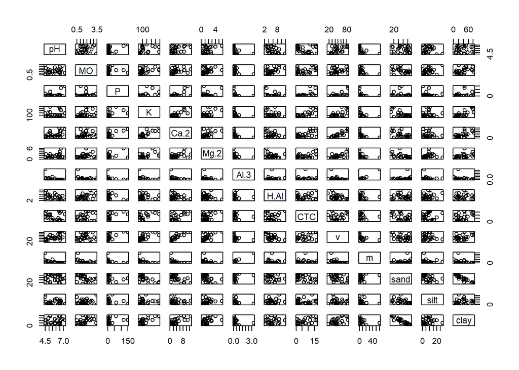

```r
soil_data = read.csv ("C:/Users/Nnamdi/Downloads/soilData.csv", header = TRUE)  # set working directory to folder with data set
soil = soil_data [ ,4:17]   # select the numeric columns or variables
rownames(soil) = soil_data [, 3]    # set row names to Soil IDs
plot(soil) # graphically explore data set and check for outliers / correlation
```

```r
soil = soil [-9,]   # remove outlier
```

Principal component analysis

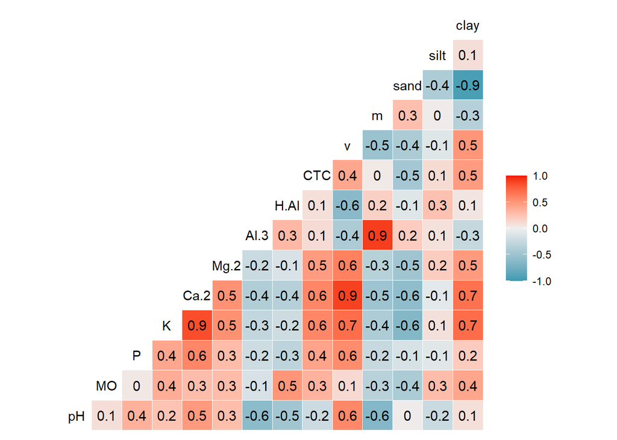

```r
ggcorr(soil, label = TRUE)  # graphical Pearson correlation result
```

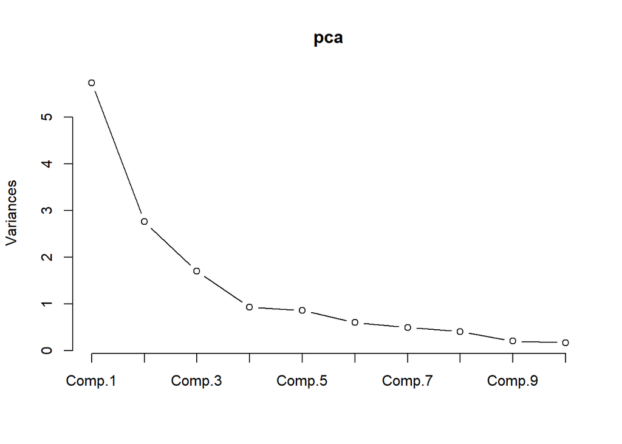

```r
pca = princomp(soil, cor = TRUE)    # principal component function
screeplot(pca, type = "lines")  # pick 4 principal components
```

```r
pca$loadings    # the contribution of variables to each principal component
```

[output not shown]

```r
summary(pca)    # the first four PCs explains ~ 80% of the variance
```

```
## Importance of components:
##                           Comp.1    Comp.2    Comp.3     Comp.4     Comp.5
## Standard deviation     2.3924082 1.6595775 1.3028443 0.96396622 0.92596604
## Proportion of Variance 0.4088298 0.1967284 0.1212431 0.06637363 0.06124379
## Cumulative Proportion  0.4088298 0.6055582 0.7268012 0.79317488 0.85441867
##                            Comp.6     Comp.7     Comp.8     Comp.9    Comp.10
## Standard deviation     0.77651028 0.70359670 0.63486860 0.45435992 0.40463922
## Proportion of Variance 0.04306916 0.03536059 0.02878987 0.01474592 0.01169521
## Cumulative Proportion  0.89748783 0.93284843 0.96163829 0.97638422 0.98807942
##                            Comp.11     Comp.12      Comp.13      Comp.14
## Standard deviation     0.355475621 0.175598786 0.0858919989 0.0480912369
## Proportion of Variance 0.009025923 0.002202495 0.0005269597 0.0001651976
## Cumulative Proportion  0.997105347 0.999307843 0.9998348024 1.0000000000
```

```r
pca$sdev    # standard deviation of PCs
```

```
##     Comp.1     Comp.2     Comp.3     Comp.4     Comp.5     Comp.6     Comp.7
## 2.39240817 1.65957749 1.30284425 0.96396622 0.92596604 0.77651028 0.70359670
##     Comp.8     Comp.9    Comp.10    Comp.11    Comp.12    Comp.13    Comp.14
## 0.63486860 0.45435992 0.40463922 0.35547562 0.17559879 0.08589200 0.04809124
```

```r
pca.var = pca$sdev^2    # eigenvalues of the principal components
pca$scores # values of the principal components / new variables
```

```
##          Comp.1     Comp.2      Comp.3      Comp.4       Comp.5      Comp.6
## S1  -2.57843483  0.2290742 -0.98765158 -0.18551012 -1.298476731 -0.40047179
## S2  -0.75554126 -3.5480651  0.91395134  0.81388460  2.249808922 -1.45259090
## S3  -3.27301387 -0.7084288 -0.40632311  1.40717890 -0.383032991 -0.18232916
## S4  -1.42857110 -3.7127091 -0.11066895  1.59443567  0.115476409  1.08750461
## S5  -0.99795576  1.1476105  0.96791558 -0.84105997  1.023189741 -0.15329590
## S6  -0.91420695  0.6778680  1.39110795 -0.43186989  0.466632446  0.02694646
## S7   0.91460425  0.8123378  1.01130694 -1.13408716  0.824260172  0.61762176
## S8  -2.12335546 -1.8870978 -1.29266027 -2.81445227  0.388068889 -0.84855400
## S10 -2.36109236 -0.2505623 -1.73319570  0.77067310 -0.002475554  0.33220563
## S11 -3.71912692  0.1012126 -3.28532446 -0.40336031  0.405240118  1.36091081
## S12 -0.85825246  1.7293828  0.93821401  0.25581168 -0.023587231  0.30775969
## S13 -1.11621006  1.9575039  1.11649181  0.37567417  0.055337693  0.37916919
## S14 -1.49642445  1.6879403  1.31919780 -0.53794640  0.076471212 -0.70065394
## S15  0.44063393  0.6618504  2.10798107  1.18661255 -1.219427572  0.57351503
## S16  0.12056194 -0.4080321  1.96203641 -0.56271232  0.702579214 -0.12951798
## S17 -0.82226506 -1.6062395  1.48920519  0.34331586 -0.470630339 -0.24760623
## S18  0.49199666 -1.3672064  0.11266996  0.31333922 -1.082093393 -0.07256423
## S19  3.25071035  2.7238971 -2.08739766  1.36683219  0.244791054 -2.04849632
## S20  3.17875560 -1.4530366 -0.65256878  0.46356608 -1.314602783 -1.06287832
## S21  4.57339309 -0.8858821  0.13048419 -0.37346793 -0.238184095  1.15217537
## S22  4.77401591  0.6597902 -1.62029542  0.51470751  2.227612802  0.85293964
## S23 -0.26037295  1.3172581  0.17058057  0.04985632 -0.206803757  0.37523786
## S24 -2.11775704  1.8263716 -0.80404713 -0.47433361 -0.709497585 -0.47227825
## S25  2.30295276 -1.3117381 -0.08331270 -1.43902742 -1.318453915  0.09207751
## S26  4.76172742 -0.7859136 -0.53030939 -0.77213886 -0.766428422  0.20746735
## S27  0.01322862  2.3928139 -0.03738766  0.51407839  0.254225694  0.40570611
##           Comp.7      Comp.8      Comp.9     Comp.10     Comp.11      Comp.12
## S1  -0.510253042 -0.14704935 -0.41965527 -0.56684660  0.48938531 -0.112441592
## S2   0.619353335 -1.17069066 -0.26473156 -0.27649040 -0.09171928 -0.018159681
## S3  -1.084538499 -0.14511219  0.16335180  0.12770852  0.69472091 -0.375050228
## S4  -1.022184965  0.69963856 -0.20815883  0.68236961 -0.03815394  0.287146591
## S5  -0.369975020 -0.41403805  0.41679077 -0.08683058 -0.19479010  0.052618704
## S6  -0.289855044 -0.14762223  0.19424928 -0.38599679 -0.01105000  0.133059096
## S7   0.069356566  0.34178228 -0.06911292  0.57263917 -0.32733033 -0.312604960
## S8  -0.143937077  0.64950398 -0.64431319 -0.04508852  0.22780906 -0.008804318
## S10  0.107676547 -0.82543506 -0.15250763  0.56219601 -0.32978848  0.123382349
## S11  1.869687713  0.25162851  0.60413734 -0.20157047 -0.06936261  0.012530005
## S12 -0.211161301  0.08970272  0.57686053  0.47985779 -0.12545708 -0.174063028
## S13  0.008347817 -0.06714834  0.30526684  0.03795695  0.28299793  0.152646164
```

[output cut: 26 more lines]

```
## S13  0.026982617 -0.038203210
## S14 -0.076285343  0.023049027
## S15 -0.038928114 -0.050282907
## S16  0.022744318  0.063099310
## S17 -0.065435910  0.001183411
## S18 -0.073992673 -0.058669394
## S19  0.043972940  0.011264720
## S20  0.129352382 -0.008379603
## S21  0.097513629  0.047673036
## S22 -0.136854388 -0.031431673
## S23 -0.004361069 -0.015670895
## S24 -0.068457961  0.047296140
## S25 -0.066979860  0.071007938
## S26 -0.053215197 -0.033962350
## S27  0.191680395  0.012151119
```

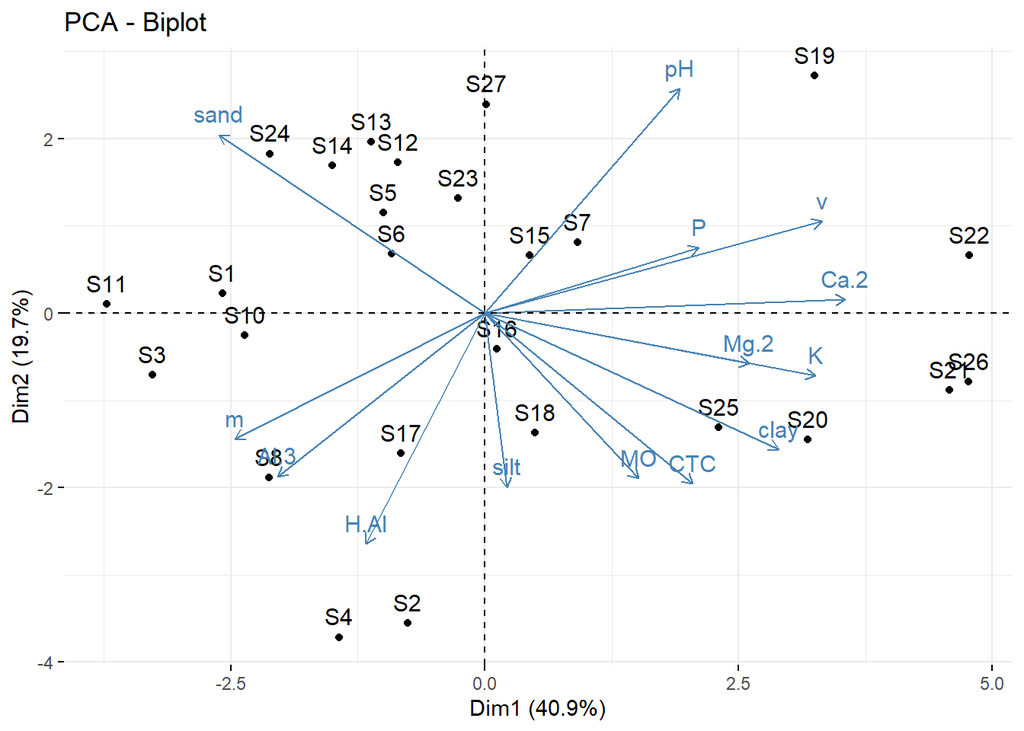

```r
fviz_pca_biplot (pca)   # biplot of PCA
```

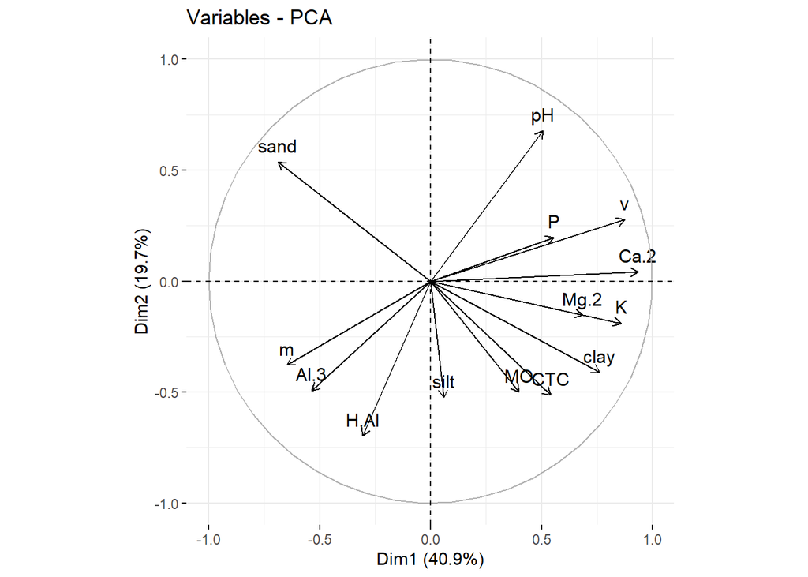

```r
fviz_pca_var (pca)  # graph of variables
```

```r
PCs = as.data.frame(pca$scores[,1:4])   # a new data frame of the scores of the principal components
```

K-means clustering

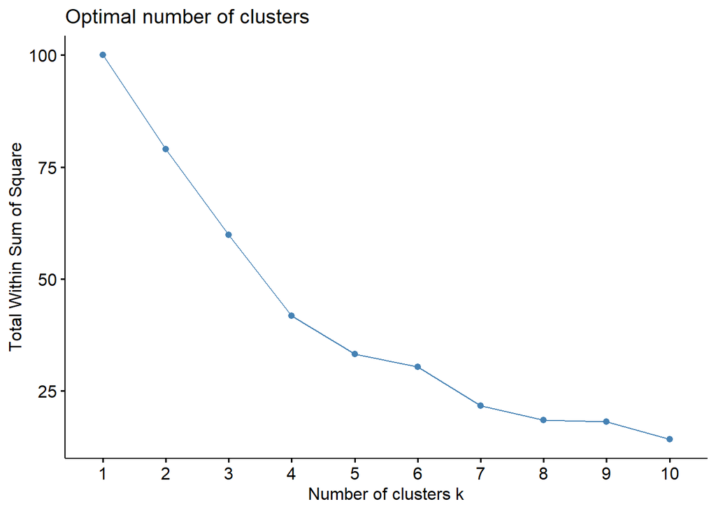

```r
my_data = scale(PCs [,1:4])     # scales data to eliminate effect of variance
fviz_nbclust(my_data, kmeans, method = "wss")   # compute total within-cluster sum of square
```

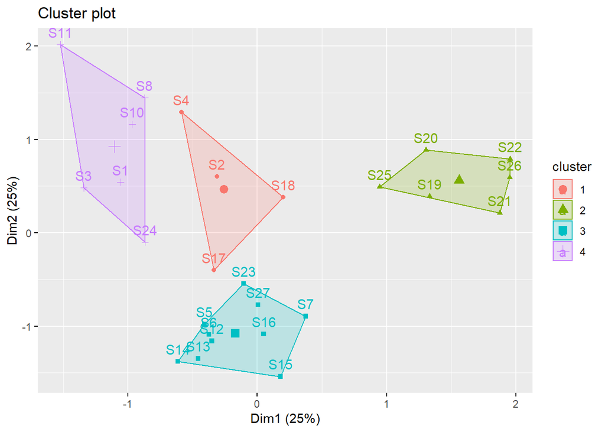

```r
groups = kmeans(PCs, centers = 4, nstart = 25)  # group into clusters
fviz_cluster(groups, data = PCs)    # cluster plot
```

Linear discriminant analysis

```r
mvn(my_data,mvnTest = "mardia")     # test of multivariate normality
```

```
## $multivariateNormality
##              Test         Statistic            p value Result
## 1 Mardia Skewness  31.1154564528815 0.0536845747416254    YES
## 2 Mardia Kurtosis -0.24438371771963  0.806933650922301    YES
## 3             MVN              <NA>               <NA>    YES
##
## $univariateNormality
##               Test  Variable Statistic   p value Normality
## 1 Anderson-Darling  Comp.1      0.8157    0.0302    NO
## 2 Anderson-Darling  Comp.2      0.2759    0.6291    YES
## 3 Anderson-Darling  Comp.3      0.2783    0.6211    YES
## 4 Anderson-Darling  Comp.4      0.3122    0.5283    YES
##
## $Descriptives
##         n          Mean Std.Dev      Median       Min      Max       25th
## Comp.1 26 -2.397242e-17       1 -0.32334917 -1.524365 1.956735 -0.6063894
## Comp.2 26  1.494531e-17       1  0.09757688 -2.193697 1.609446 -0.7121502
## Comp.3 26 -4.253865e-18       1  0.02833046 -2.472687 1.586564 -0.5766606
## Comp.4 26 -6.396793e-18       1  0.15546817 -2.862961 1.621917 -0.5310409
##             75th       Skew   Kurtosis
## Comp.1 0.3315668  0.6492424 -0.6670245
## Comp.2 0.7532577 -0.4243632 -0.5787780
## Comp.3 0.7529917 -0.4593709 -0.4444901
## Comp.4 0.5234188 -0.6420366  0.5722338
```

```r
PCs$Clusters = as.factor(groups$cluster)    # cluster results to PCs data frame
soil.lda=lda(Clusters~.,PCs)    # fits an LDA model
soil.lda    # shows details of LDA model
```

```
## Call:
## lda(Clusters ~ ., data = PCs)
##
## Prior probabilities of groups:
##         1         2         3         4
## 0.1538462 0.2307692 0.3846154 0.2307692
##
## Group means:
##       Comp.1     Comp.2     Comp.3     Comp.4
## 1 -0.6285952 -2.5585550  0.6012894  0.7662438
## 2  3.8069259 -0.1754805 -0.8072333 -0.0399214
## 3 -0.4154394  1.1976534  1.0947444 -0.1125643
## 4 -2.6954634 -0.1149051 -1.4182004 -0.2833007
##
## Coefficients of linear discriminants:
##               LD1        LD2         LD3
## Comp.1 -1.2263779  0.1525204 -0.01631822
## Comp.2  0.2196821  0.7481612 -0.55503099
## Comp.3  0.3050807  1.1333717  0.65548387
## Comp.4 -0.1955721 -0.1706094  0.65019750
##
## Proportion of trace:
##    LD1    LD2    LD3
## 0.6603 0.2478 0.0919
```

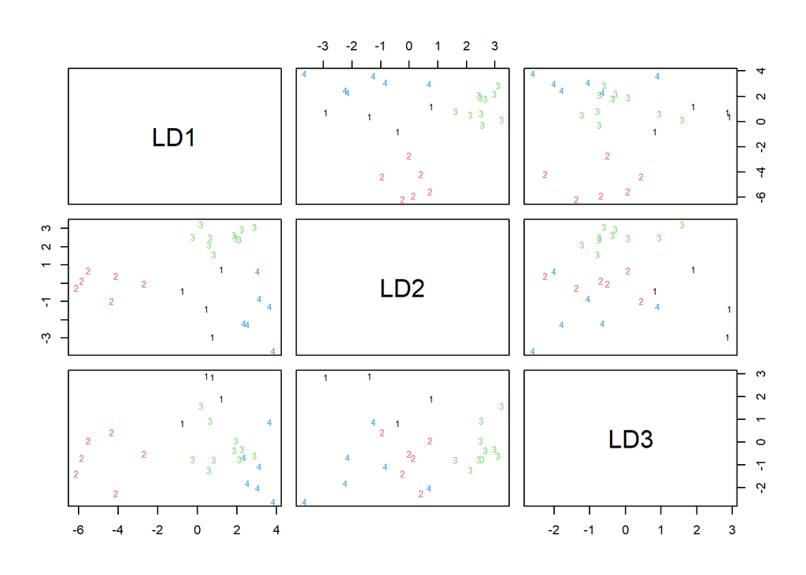

```r
plot(soil.lda, col = as.integer(PCs$Clusters))  # plot of LDA model
```

```r
soil.pred=predict(soil.lda)     # predict cluster of observations using LDA model
soil.pred   # shows posterior probability of observations
```

```
## $class
##  [1] 4 1 4 1 3 3 3 4 4 4 3 3 3 3 3 1 1 2 2 2 2 3 4 2 2 3
## Levels: 1 2 3 4
##
## $posterior
##                1            2            3            4
## S1  1.466153e-04 2.606078e-14 9.182615e-04 9.989351e-01
## S2  9.999783e-01 1.421906e-09 7.507468e-06 1.421230e-05
## S3  1.881518e-02 6.075303e-16 4.398094e-04 9.807450e-01
## S4  9.998976e-01 6.893616e-11 5.219357e-08 1.023929e-04
## S5  7.828851e-06 2.773704e-12 9.998138e-01 1.784149e-04
## S6  4.559020e-05 3.994412e-12 9.999091e-01 4.532911e-05
## S7  3.752524e-05 3.057285e-06 9.999579e-01 1.556799e-06
## S8  2.651965e-05 2.150584e-13 3.673723e-06 9.999698e-01
## S10 1.998831e-03 1.796154e-12 2.167339e-05 9.979795e-01
## S11 2.268072e-08 4.909292e-19 4.284021e-10 1.000000e+00
## S12 1.015745e-05 6.389794e-12 9.999609e-01 2.897308e-05
## S13 2.783302e-06 2.479914e-13 9.999823e-01 1.490222e-05
## S14 4.911683e-07 4.108062e-15 9.999618e-01 3.775857e-05
## S15 5.502387e-04 1.288474e-08 9.994497e-01 2.137935e-08
## S16 1.063466e-03 6.955176e-09 9.989348e-01 1.754900e-06
## S17 7.379141e-01 2.877428e-09 2.614441e-01 6.417391e-04
## S18 9.874229e-01 7.065192e-04 1.154423e-02 3.263180e-04
## S19 2.668042e-09 1.000000e+00 3.672322e-08 1.965435e-12
## S20 6.766406e-06 9.999932e-01 1.211482e-09 8.645485e-13
## S21 9.660939e-10 1.000000e+00 5.352205e-11 6.681195e-18
## S22 1.763049e-12 1.000000e+00 5.519960e-14 4.912175e-19
## S23 3.950814e-04 5.589495e-08 9.990386e-01 5.662462e-04
## S24 1.574060e-05 3.344404e-13 1.901701e-01 8.098141e-01
## S25 9.876229e-04 9.988228e-01 1.894621e-04 1.277034e-07
## S26 3.626201e-11 1.000000e+00 1.112127e-12 1.778741e-18
## S27 2.706636e-05 8.382699e-08 9.999114e-01 6.141165e-05
##
## $x
##             LD1        LD2        LD3
## S1   2.94742605 -1.3096062 -0.8530757
## S2   0.26678844 -1.8727698  3.1098813
## S3   3.45915630 -1.7298136  1.0952157
## S4   0.59076204 -3.3930459  3.0481367
## S5   1.93576065  1.9468899 -0.5330766
## S6   1.77894057  2.0180427  0.2697286
## S7  -0.41286822  2.0869281 -0.5402826
## S8   2.34553720 -2.7206008 -1.5952206
## S10  2.16106057 -2.6434149 -0.4573934
## S11  3.65988639 -4.1461962 -2.4112276
## S12  1.66865767  2.1826573 -0.1645436
## S13  2.06607266  2.4955902 -0.0921560
## S14  2.71366126  2.6215362 -0.3974987
## S15  0.01604904  2.7490552  1.7787423
## S16  0.47113851  2.0328350  1.1447122
## S17  1.04273039  0.3021119  2.1043037
## S18 -0.93063159 -0.8736128  1.0283991
## S19 -4.29234685 -0.0652781 -2.0444377
## S20 -4.50730842 -1.4209720  0.6282699
## S21 -5.69047238  0.2463576  0.2597647
## S22 -6.30478670 -0.7024465 -1.1715234
## S23  0.65098401  1.1306344 -0.5826410
## S24  2.84585870  0.2130606 -1.8145853
## S25 -2.85643913 -0.4790567 -0.2997870
## S26 -6.02310660 -0.3310327 -0.4911486
## S27  0.39748946  1.6621473 -1.0185562
```

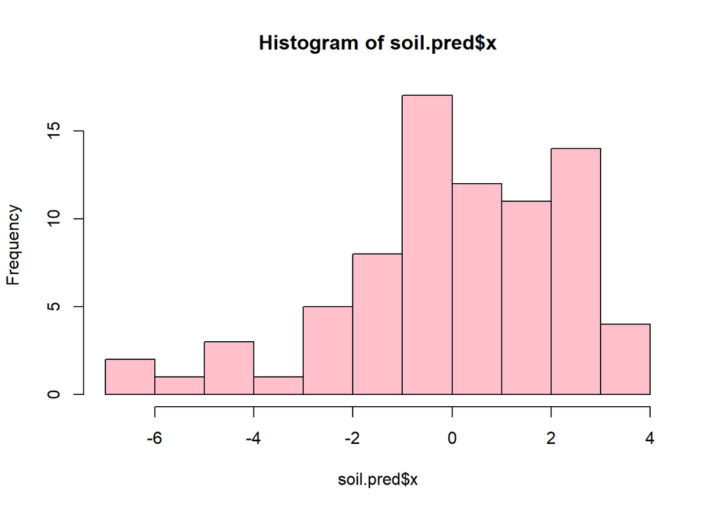

```r
hist(soil.pred$x, col="pink")   # histogram of projections
```

```r
table(PCs$Clusters,soil.pred$class,dnn=c("From","Classified into"))     # accuracy table
```

```
##     Classified into
## From  1  2  3  4
##    1  4  0  0  0
##    2  0  6  0  0
##    3  0  0 10  0
##    4  0  0  0  6
```

```r
soil.ldacv = lda(Clusters~.,PCs, CV=TRUE)   # evaluation of LDA model with cross-validation
table(PCs$Clusters,soil.ldacv$class,dnn=c("From","Classified into"))    # accuracy of LDA
```

```
##     Classified into
## From  1  2  3  4
##    1  3  0  1  0
##    2  0  6  0  0
##    3  0  0 10  0
##    4  0  0  1  5
```